# CO2 Analysis

```r
library(tseries)
library(TSA)
library(fpp)
library(fpp2)
library(ggplot2)
library(forecast)
```

```r
setwd("C:/Users/Taylor/Documents/MSCA/Time Series Analysis & Forecasting/Final Project/31006_Project_files/31006_Project_files/")
path <- paste(getwd(), "/csv_files/", sep = "")
files <- dir(path, pattern = ".csv")
# Drop 1st and last file to deal with later
files <- files[-1]
```

#### Load time series data

```r
dat <- load(paste(path,'Monthly_Data.RData',sep = ''))
dat <- load(paste(path,'Time_Series.RData',sep = ''))
```

#### Set forecast length for any future forecasts

```r
forecastlength<-12
```

#### Get CO2 emissions for electricity

```r
All_CO2<-monthly_dta_ts$CO2_ElecPower
All_CO2<-window(All_CO2,start=2019)
rbind(monthly_meta$CO2_ElecPower, colSums(All_CO2))
```

```
##        V1                                       V2
## 1   Month Coal Electric Power Sector CO2 Emissions
## 2    <NA>  (Million Metric Tons of Carbon Dioxide)
## 3 902.464                                  569.498
##                                                V3
## 1 Natural Gas Electric Power Sector CO2 Emissions
## 2         (Million Metric Tons of Carbon Dioxide)
## 3                                           3.429
##                                                                                           V4
## 1 Distillate Fuel, Including Kerosene-Type Jet Fuel, Oil Electric Power Sector CO2 Emissions
## 2                                                    (Million Metric Tons of Carbon Dioxide)
## 3                                                                                      7.501
##                                                   V5
## 1 Petroleum Coke Electric Power Sector CO2 Emissions
## 2            (Million Metric Tons of Carbon Dioxide)
```

[output cut: 21 more lines]

### Total CO2 Emissions data

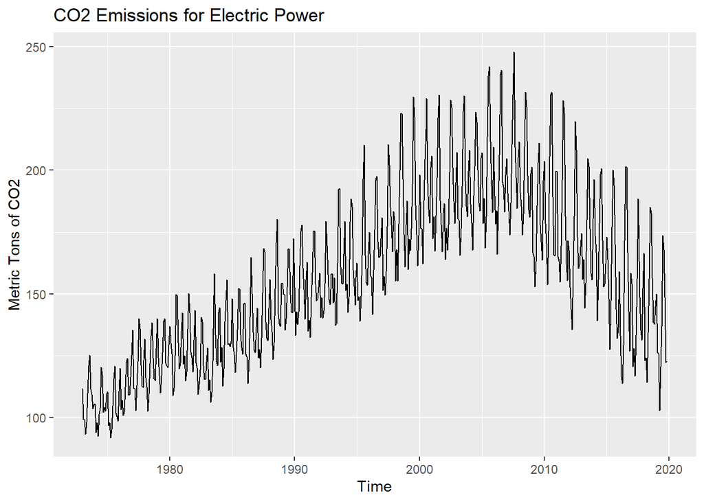

```r
total_Co2<-monthly_dta_ts$CO2_ElecPower[,"V10"]
autoplot(total_Co2,ylab="Metric Tons of CO2") +
    ggtitle("CO2 Emissions for Electric Power")
```

#### Look at small window of time to see seasonality

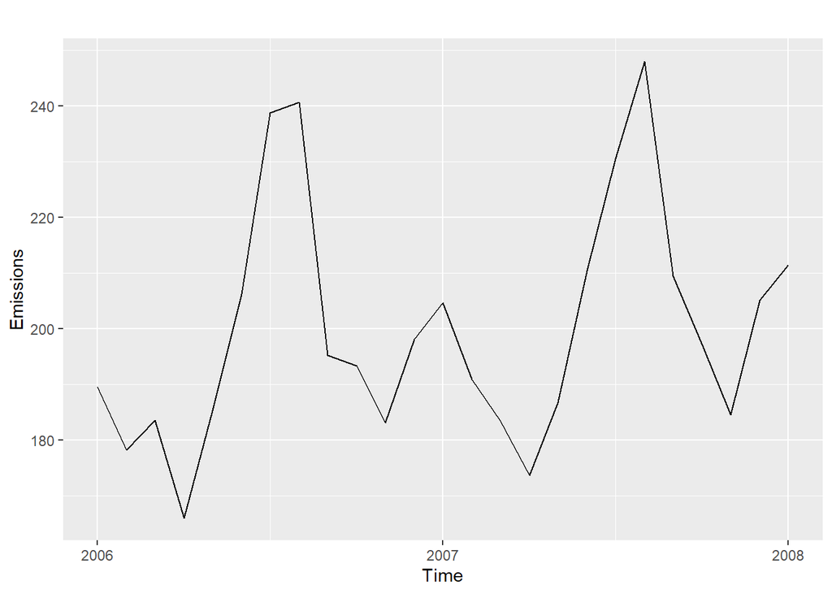

```r
autoplot(cbind("CO2 Emission"  = window(total_Co2,start=2006,end=2008)),ylab="Emissions")
```

### Has large peak in summer and a smaller peak in the winter (makes sense - AC and heat respectively)

### Decomposition with multiplicative seasonality

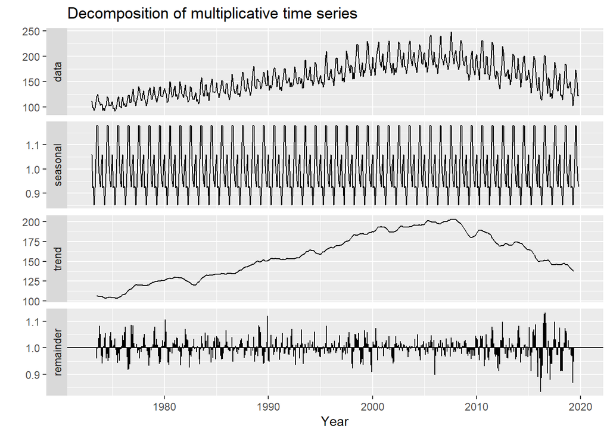

```r
total_Co2 %>% decompose(type="multiplicative") %>% autoplot + xlab("Year")
```

### Fit Holt-Winter SES model with multiplicative seasonality (seasonality changes to a small degree - model fits better ). HW does not require stationarity so no need for transformations

```r
fit_hw_mult<-hw(total_Co2,h=forecastlength,seasonal="multiplicative")
summary(fit_hw_mult$model)
```

```
## Holt-Winters' multiplicative method
##
## Call:
##  hw(y = total_Co2, h = forecastlength, seasonal = "multiplicative")
##
##   Smoothing parameters:
##     alpha = 0.4141
##     beta  = 2e-04
##     gamma = 0.1969
##
##   Initial states:
##     l = 107.0997
##     b = 0.0104
##     s = 1.0699 0.9611 0.9801 0.9717 1.1108 1.1014
##            1.0037 0.9602 0.8825 0.9582 0.9395 1.061
##
##   sigma:  0.0415
##
##      AIC     AICc      BIC
## 5664.766 5665.889 5738.432
##
## Training set error measures:
##                     ME     RMSE      MAE         MPE     MAPE      MASE
## Training set 0.1530397 6.498375 4.960214 -0.07536496 3.171787 0.6533311
##                   ACF1
## Training set 0.2199202
```

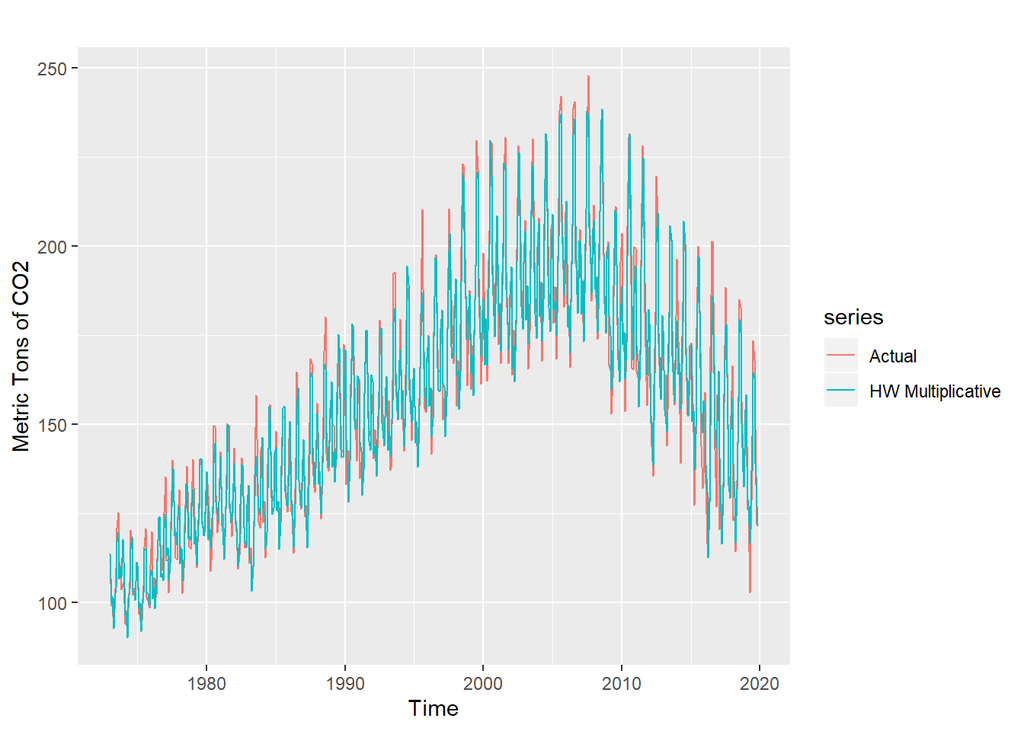

```r
autoplot(cbind(Actual=total_Co2,"HW Multiplicative"=fit_hw_mult$fitted), xlab='Time',ylab="Metric Tons of CO2", facets=FALSE)
```

```r
model_func_hw <- function(x, h){hw(x,h=h,seasonal="multiplicative")}
error1hw <- tsCV(total_Co2, model_func_hw, h=12)
error2hw <- tsCV(total_Co2, model_func_hw, h=12, window = 48)
RMS1hw<-sqrt(mean(error1hw^2, na.rm=TRUE))
RMS2hw<-sqrt(mean(error2hw^2, na.rm=TRUE))
c(RMS1hw,RMS2hw)
```

```
## [1] 10.18838 10.70348
```

## ARIMA/SARIMA models

#### ARIMA/SARIMA models require stationarity - investigate how time series gets to stationarity.

#### Break up time series into windows based on interventions/changes in trend

#### Work with last window (2008 and onwards) as this will be used in forecasting

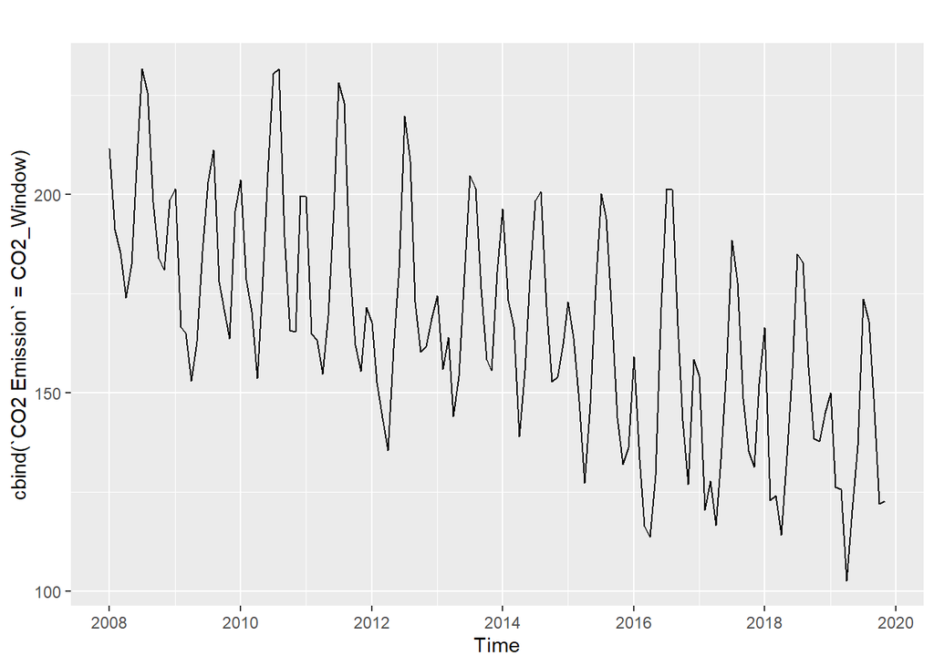

```r
CO2_Window<-window(total_Co2,start=2008)
autoplot(cbind("CO2 Emission"  = CO2_Window))
```

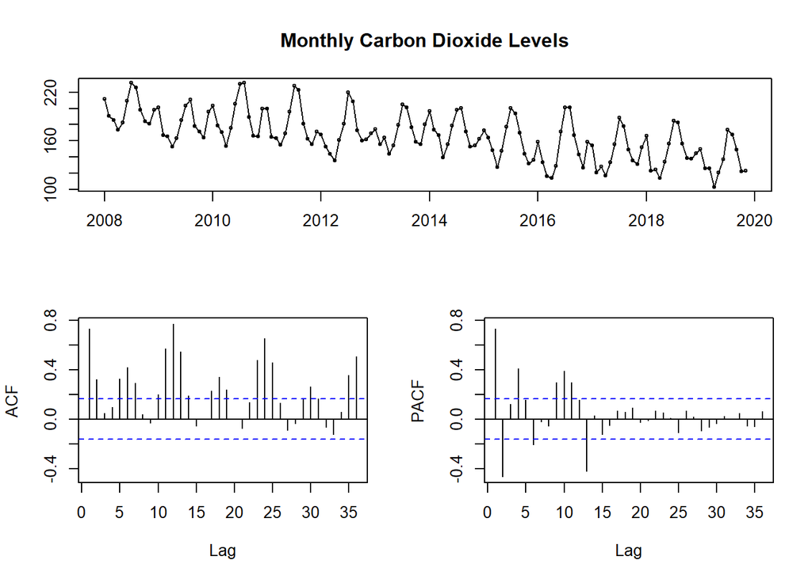

```r
tsdisplay(CO2_Window,main='Monthly Carbon Dioxide Levels')
```

#### There is trend, the ACF does not die down - not stationary

#### Is variance not constant with level?

```r
lambda_rec<-BoxCox.lambda(CO2_Window)
lambda_rec
```

```
## [1] 1.072681
```

### Not a strong transformation

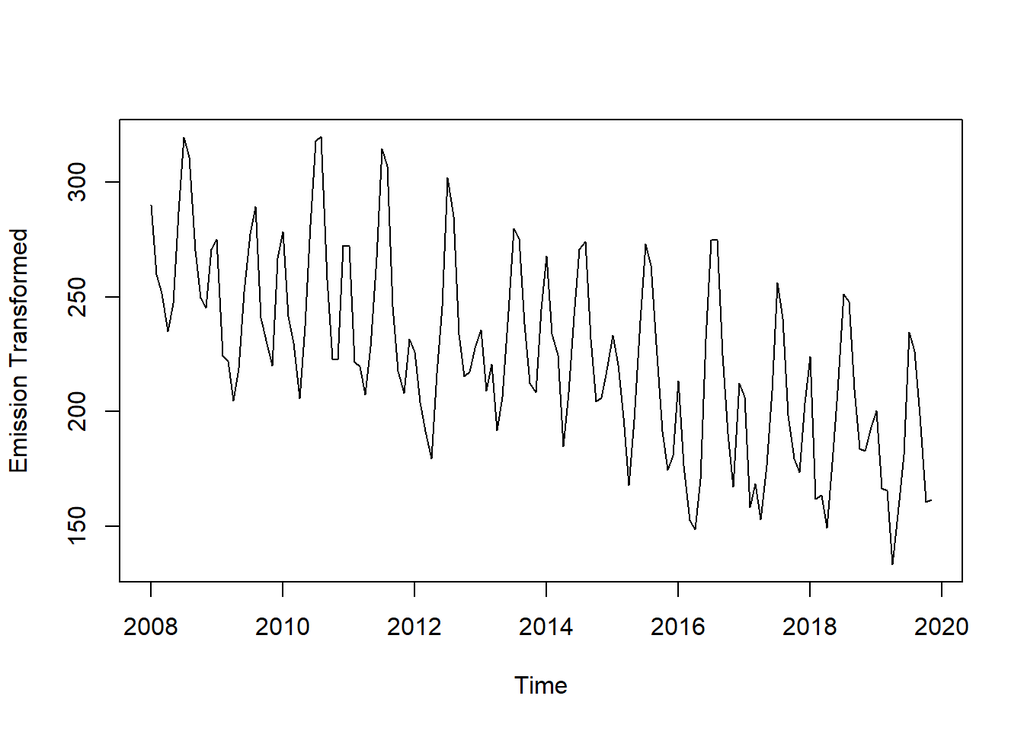

```r
CO2_Window_trf<-BoxCox(CO2_Window,lambda=lambda_rec)
plot(CO2_Window_trf,ylab='Emission Transformed')
```

#### kpss - null hypothesis is stationary, alternative is non-stationary

```r
kpss.test(CO2_Window_trf)
```

```
##
##  KPSS Test for Level Stationarity
##
## data:  CO2_Window_trf
## KPSS Level = 2.0101, Truncation lag parameter = 4, p-value = 0.01
```

#### p value of .01<.05 –>non-stationary

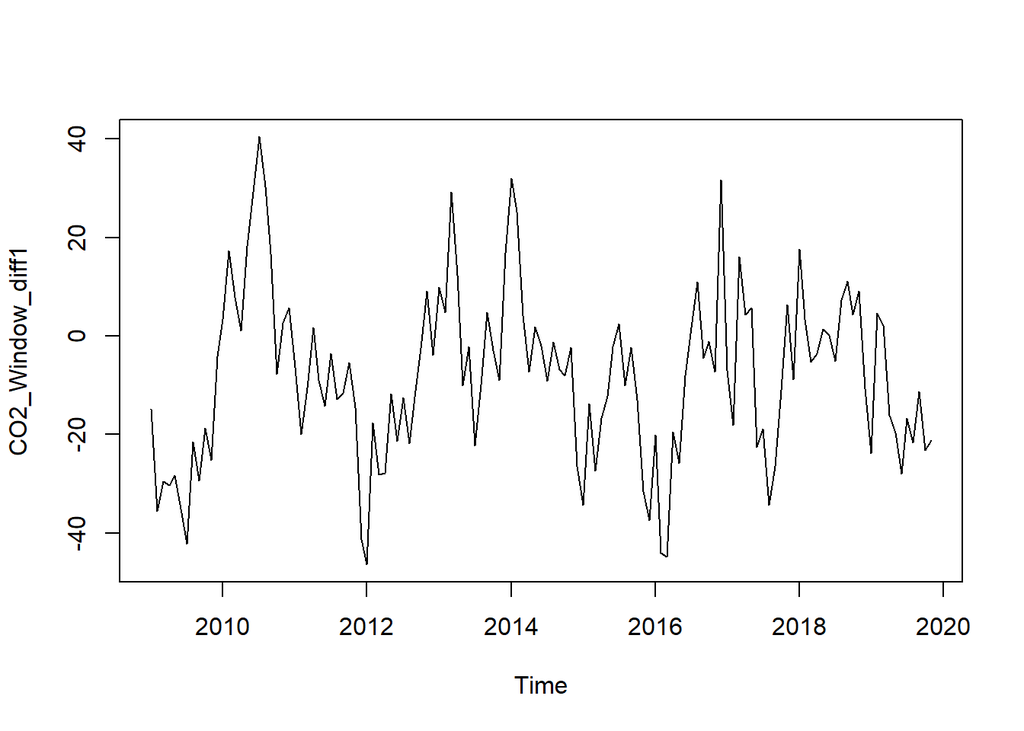

```r
CO2_Window_diff1<-diff(CO2_Window_trf,lag=12)
plot(CO2_Window_diff1)
```

```r
kpss.test(CO2_Window_diff1)
```

```
##
##  KPSS Test for Level Stationarity
##
## data:  CO2_Window_diff1
## KPSS Level = 0.058326, Truncation lag parameter = 4, p-value = 0.1
```

### p-value > .05 means series is stationary

### Seasonal differece of 1 gets to stationary

#### Do my own SARIMA modeling & then compare to auto.arima()

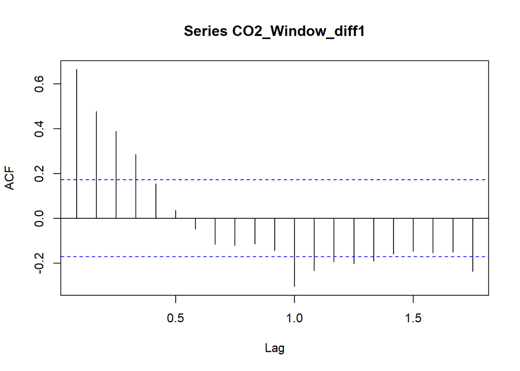

```r
acf(CO2_Window_diff1)
```

#### Sinusoidal decay implies AR() process

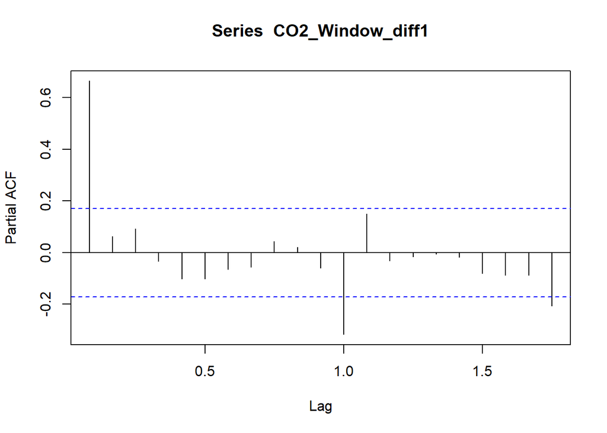

```r
pacf(CO2_Window_diff1)
```

#### Spikes at 1, 12,((AR() characteristic) but there seems to be some sinusoidal behavior later as well - might have MA() order?

```r
eacf(CO2_Window_diff1)
```

```
## AR/MA
##   0 1 2 3 4 5 6 7 8 9 10 11 12 13
## 0 x x x x o o o o o o o  x  x  x
## 1 o o o o o o o o o o o  x  o  o
## 2 x o o o o o o o o o o  x  o  o
## 3 x x o o o o o o o o o  x  o  o
## 4 x x o o o o o o o o o  x  o  o
## 5 x o o o o o o o o o o  x  o  o
## 6 x x o x o o o o o o o  x  o  o
## 7 x o o x o o o o o o x  x  o  o
```

### Attempt various sARIMA model orders

`r CO2_arima1<-Arima(CO2_Window,order=c(0,0,1),seasonal=list(order=c(1,1,1),period=12),lambda="auto") CO2_arima1`

`## Series: CO2_Window ## ARIMA(0,0,1)(1,1,1)[12] ## Box Cox transformation: lambda= 1.072681 ## ## Coefficients: ## ma1 sar1 sma1 ## 0.6089 -0.0565 -0.2378 ## s.e. 0.0569 0.2249 0.2075 ## ## sigma^2 estimated as 213.5: log likelihood=-536.43 ## AIC=1080.87 AICc=1081.19 BIC=1092.37`

###Apply non-seasonal difference

`r CO2_arima2<-Arima(CO2_Window,order=c(0,1,1),seasonal=list(order=c(1,0,1),period=12),lambda="auto",method="ML") CO2_arima2`

`## Series: CO2_Window ## ARIMA(0,1,1)(1,0,1)[12] ## Box Cox transformation: lambda= 1.072681 ## ## Coefficients: ## ma1 sar1 sma1 ## -0.2755 0.9999 -0.9548 ## s.e. 0.1060 0.0007 0.1324 ## ## sigma^2 estimated as 113: log likelihood=-560.43 ## AIC=1128.87 AICc=1129.16 BIC=1140.69`

### Need seasonal difference

### Revert difference, increase p order to 1

`r CO2_arima3<-Arima(CO2_Window,order=c(1,0,1),seasonal=list(order=c(1,1,1),period=12),lambda="auto") CO2_arima3`

`## Series: CO2_Window ## ARIMA(1,0,1)(1,1,1)[12] ## Box Cox transformation: lambda= 1.072681 ## ## Coefficients: ## ar1 ma1 sar1 sma1 ## 0.9889 -0.3130 0.1890 -0.9997 ## s.e. 0.0404 0.1111 0.0979 0.1938 ## ## sigma^2 estimated as 109: log likelihood=-503.96 ## AIC=1017.91 AICc=1018.39 BIC=1032.29`

### Improvement but barely stationary

`r CO2_arima3 %>% autoplot()`

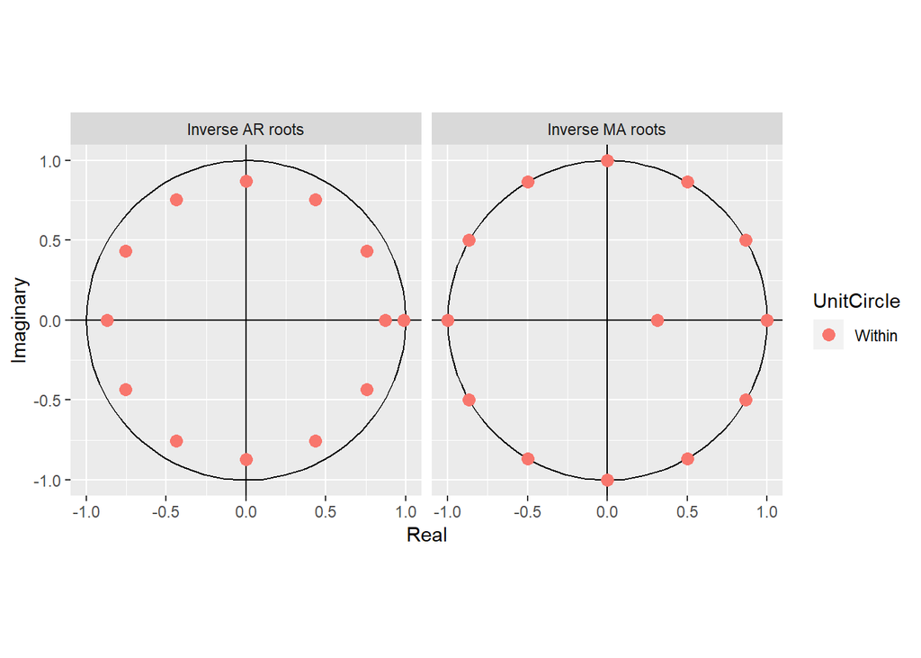

### Moving average roots are on unit circle

### Increase p order again

`r CO2_arima4<-Arima(CO2_Window,order=c(2,0,0),seasonal=list(order=c(1,1,1),period=12),lambda="auto") CO2_arima4`

`## Series: CO2_Window ## ARIMA(2,0,0)(1,1,1)[12] ## Box Cox transformation: lambda= 1.072681 ## ## Coefficients: ## ar1 ar2 sar1 sma1 ## 0.7574 0.2007 0.1938 -0.9994 ## s.e. 0.0859 0.0886 0.0992 0.2605 ## ## sigma^2 estimated as 110.6: log likelihood=-505.15 ## AIC=1020.29 AICc=1020.77 BIC=1034.67`

`r forecast_arim4<-forecast(CO2_arima4,h=24) plot(forecast_arim4$mean)`

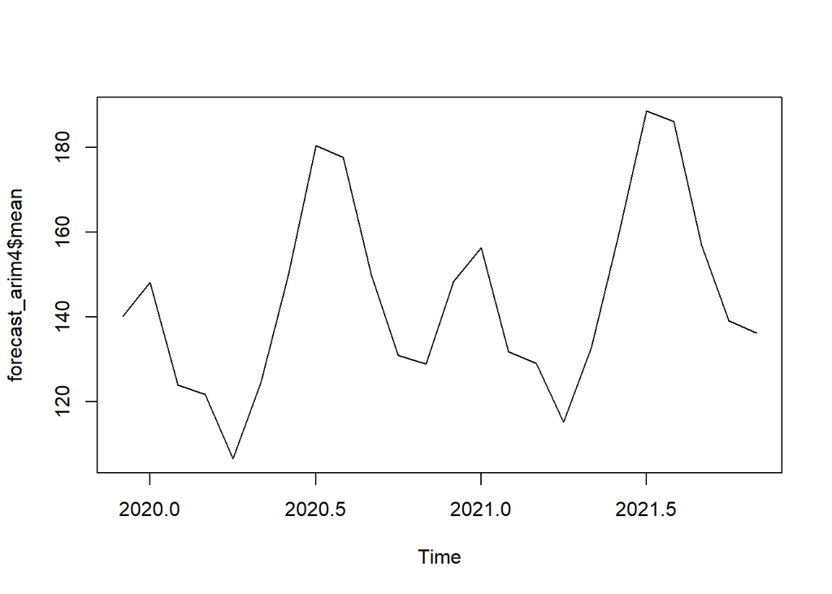

### Not better

### Increase P order

`r CO2_arima5<-Arima(CO2_Window,order=c(1,0,0),seasonal=list(order=c(2,1,0),period=12),lambda="auto",include.drift=TRUE) CO2_arima5`

`## Series: CO2_Window ## ARIMA(1,0,0)(2,1,0)[12] with drift ## Box Cox transformation: lambda= 1.072681 ## ## Coefficients: ## ar1 sar1 sar2 drift ## 0.6244 -0.4582 -0.3181 -0.6303 ## s.e. 0.0692 0.0857 0.0883 0.1302 ## ## sigma^2 estimated as 133.4: log likelihood=-506.64 ## AIC=1023.27 AICc=1023.75 BIC=1037.65`

`r forecast_arim5<-forecast(CO2_arima5,h=24) plot(forecast_arim5$mean)`

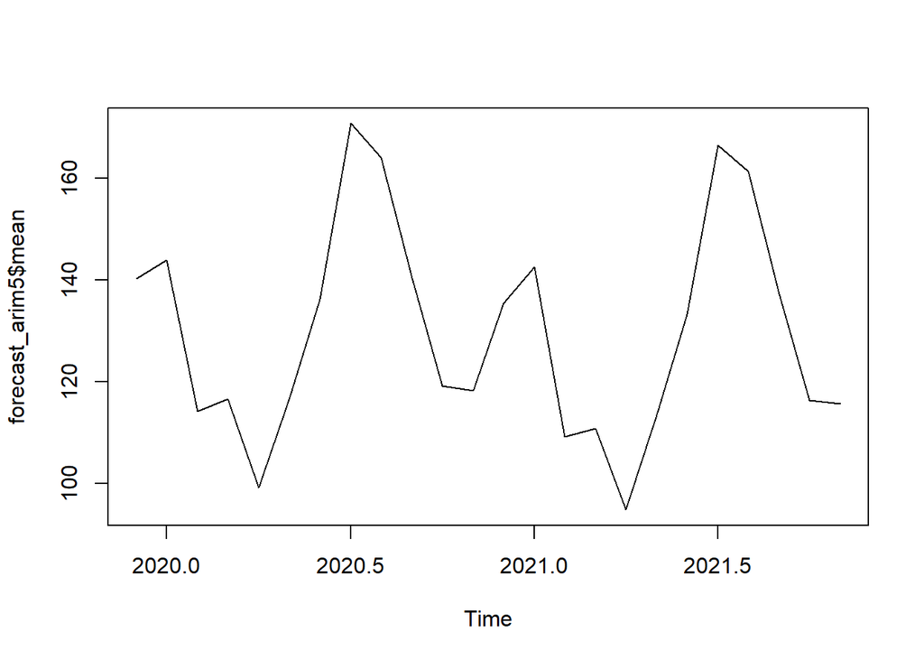

`r autoplot(cbind("Actual"=CO2_Window,"SARIMA Fitted"=CO2_arima5$fitted), xlab='Time',ylab="Metric Tons of CO2", facets=FALSE)`

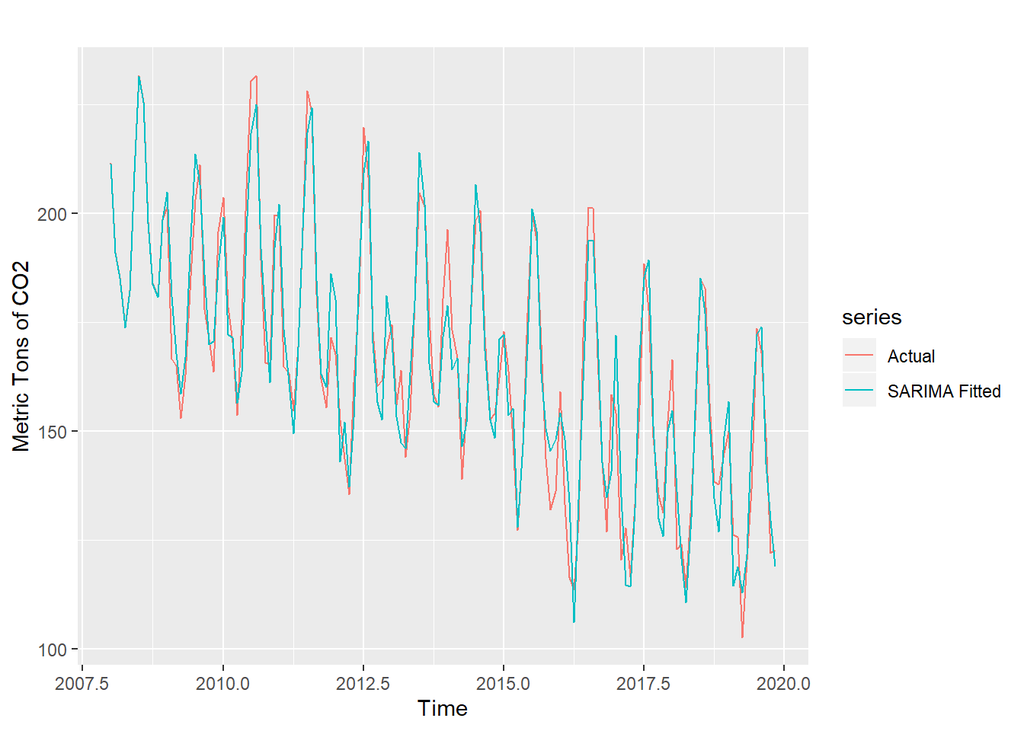

## Run Autoarima

```r
CO2_autoarima_1<-auto.arima(CO2_Window, seasonal = TRUE, trace = TRUE, lambda="auto")
```

```
##
##  ARIMA(2,0,2)(1,1,1)[12] with drift         : Inf
##  ARIMA(0,0,0)(0,1,0)[12] with drift         : 1121.965
##  ARIMA(1,0,0)(1,1,0)[12] with drift         : 1033.502
##  ARIMA(0,0,1)(0,1,1)[12] with drift         : Inf
##  ARIMA(0,0,0)(0,1,0)[12]                    : 1145.902
##  ARIMA(1,0,0)(0,1,0)[12] with drift         : 1047.876
##  ARIMA(1,0,0)(2,1,0)[12] with drift         : 1023.755
##  ARIMA(1,0,0)(2,1,1)[12] with drift         : Inf
##  ARIMA(1,0,0)(1,1,1)[12] with drift         : Inf
##  ARIMA(0,0,0)(2,1,0)[12] with drift         : 1082.21
##  ARIMA(2,0,0)(2,1,0)[12] with drift         : Inf
##  ARIMA(1,0,1)(2,1,0)[12] with drift         : 1025.89
##  ARIMA(0,0,1)(2,1,0)[12] with drift         : 1041.373
##  ARIMA(2,0,1)(2,1,0)[12] with drift         : 1028.143
##  ARIMA(1,0,0)(2,1,0)[12]                    : 1033.954
##
##  Best model: ARIMA(1,0,0)(2,1,0)[12] with drift
```

```r
CO2_autoarima_1
```

```
## Series: CO2_Window
## ARIMA(1,0,0)(2,1,0)[12] with drift
## Box Cox transformation: lambda= 1.072681
##
## Coefficients:
##          ar1     sar1     sar2    drift
##       0.6244  -0.4582  -0.3181  -0.6303
## s.e.  0.0692   0.0857   0.0883   0.1302
##
## sigma^2 estimated as 133.4:  log likelihood=-506.64
## AIC=1023.27   AICc=1023.75   BIC=1037.65
```

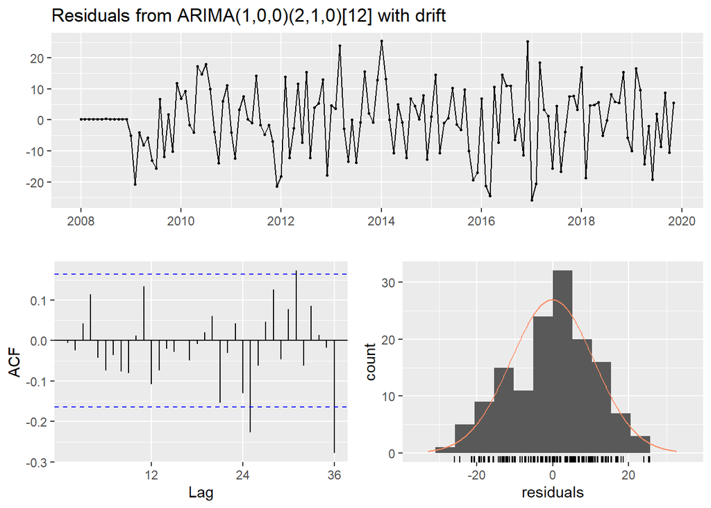

```
##
##  Ljung-Box test
##
## data:  Residuals from ARIMA(1,0,0)(2,1,0)[12] with drift
## Q* = 19.726, df = 20, p-value = 0.4752
##
## Model df: 4.   Total lags used: 24
```

```r
checkresiduals(CO2_autoarima_1)
```

### P-value of ljung-box test well above confidence tnreshold - no correlated errors

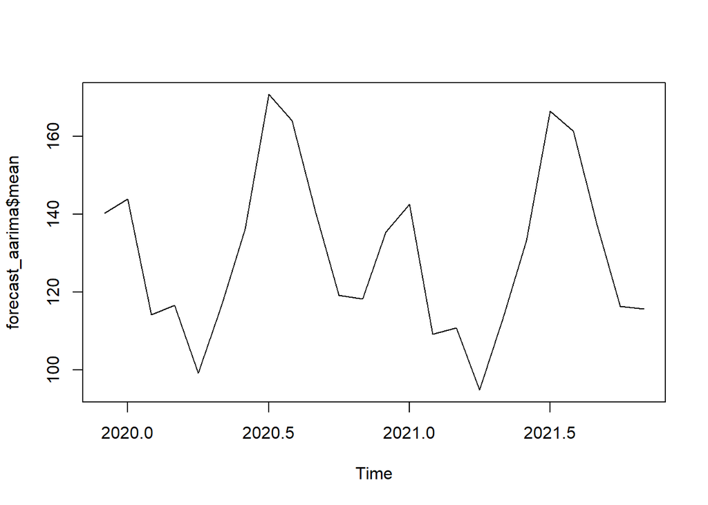

```r
forecast_aarima<-forecast(CO2_autoarima_1,h=24)
plot(forecast_aarima$mean)
```

### Returning to CO2_arima5

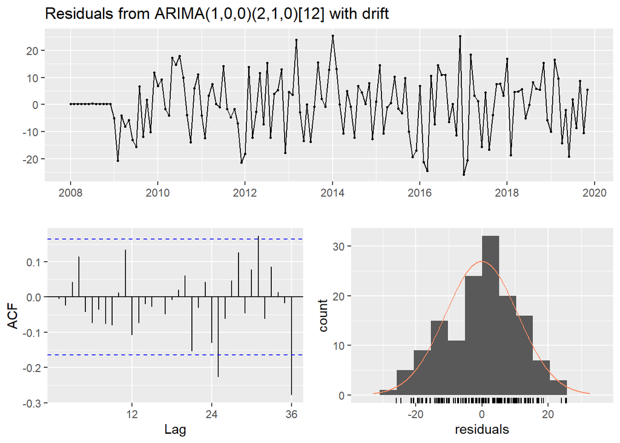

```
##
##  Ljung-Box test
##
## data:  Residuals from ARIMA(1,0,0)(2,1,0)[12] with drift
## Q* = 19.726, df = 20, p-value = 0.4752
##
## Model df: 4.   Total lags used: 24
```

```r
checkresiduals(CO2_arima5)
```

### Perform Cross-Validation testing on 2 SARIMA model levels to confirm model isn’t overfit ### Create train subset

`r CO2_Window_subset<-window(CO2_Window,end=2018)`

### Run tsCV() with top SARIMA models to test overfitting

`r model_func1_SAR <- function(x, h){forecast(Arima(x,order=c(1,0,0),seasonal=list(order=c(2,1,0),period=12),lambda="auto",include.drift = TRUE), h=h)} model_func2_SAR <- function(x, h){forecast(Arima(x,order=c(1,0,1),seasonal=list(order=c(1,1,1),period=12),lambda="auto",include.drift = TRUE), h=h)} error_1 <- tsCV(CO2_Window, model_func1_SAR, h=12) error_2 <- tsCV(CO2_Window, model_func1_SAR, h=12, window = 48) error_3 <- tsCV(CO2_Window, model_func2_SAR, h=12) error_4 <- tsCV(CO2_Window, model_func2_SAR, h=12, window = 48)`

`r autoplot(error_1[,"h=12"], series='Model 1 Expanding Window') + autolayer(error_2[,"h=12"], series = 'Model 1 Rolling Window') + autolayer(error_3[,"h=12"], series = 'Model 2 Expanding Window') + autolayer(error_4[,"h=12"], series = 'Model 2 Rolling Window') + geom_hline(yintercept=0)`

`## Warning: Removed 62 rows containing missing values (geom_path).`

`## Warning: Removed 37 rows containing missing values (geom_path).`

`## Warning: Removed 59 rows containing missing values (geom_path).`

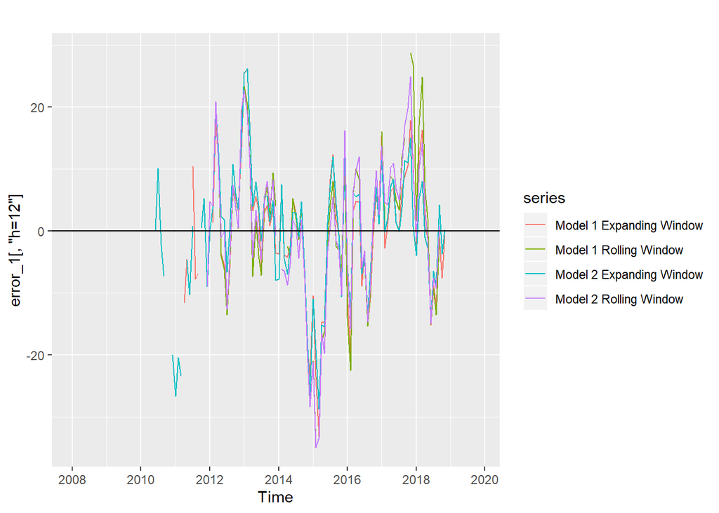

`r RMS_1<-sqrt(mean(error_1^2, na.rm=TRUE)) RMS_2<-sqrt(mean(error_2^2, na.rm=TRUE)) RMS_3<-sqrt(mean(error_3^2, na.rm=TRUE)) RMS_4<-sqrt(mean(error_4^2, na.rm=TRUE)) c(RMS_1,RMS_2,RMS_3,RMS_4)`

`## [1] 10.635671 11.321635 9.843325 11.214296`

`r CO2_arima5$coef`

`## ar1 sar1 sar2 drift ## 0.6243767 -0.4582321 -0.3180909 -0.6302694`

### Regression with ARIMA analysis with covariate consumption for electricity

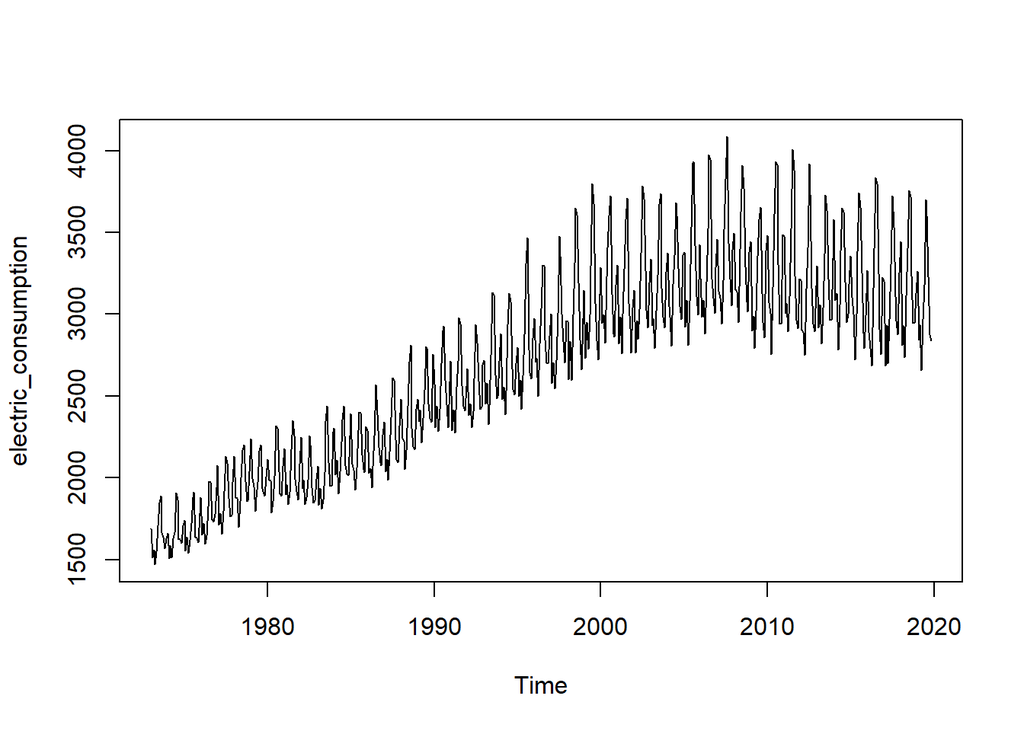

```r
electric_consumption<-monthly_dta_ts$Consump_Elec[,"V14"]
plot(electric_consumption)
```

#### Get window same as CO2 Emissions

```r
consumption_window<-window(electric_consumption,start=2008)
```

#### Get model to forecast consumption for emissions forecast

```r
Consumption_autoarima1<-auto.arima(consumption_window)
Consumption_autoarima1
```

```
## Series: consumption_window
## ARIMA(1,0,0)(2,1,1)[12] with drift
##
## Coefficients:
##          ar1    sar1     sar2     sma1    drift
##       0.4866  0.0698  -0.2426  -0.8514  -1.4175
## s.e.  0.0786  0.1101   0.1046   0.1492   0.3089
##
## sigma^2 estimated as 6524:  log likelihood=-768.41
## AIC=1548.82   AICc=1549.5   BIC=1566.07
```

#### Try using seasonal naive

```r
Consumption_naive<-snaive(consumption_window,h=forecastlength)
```

#### Create consumption forecast

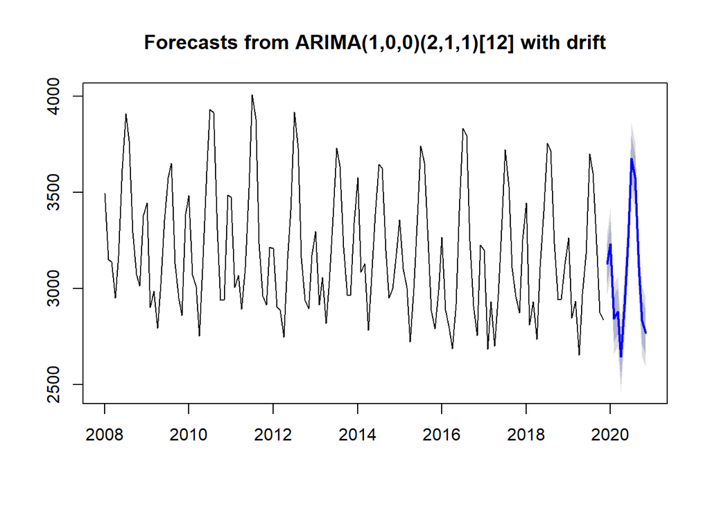

```r
consumption_forecast<-forecast(Consumption_autoarima1,h=forecastlength)
plot(consumption_forecast)
```

#### Perform regression with ARIMA errors for CO2 Emissions

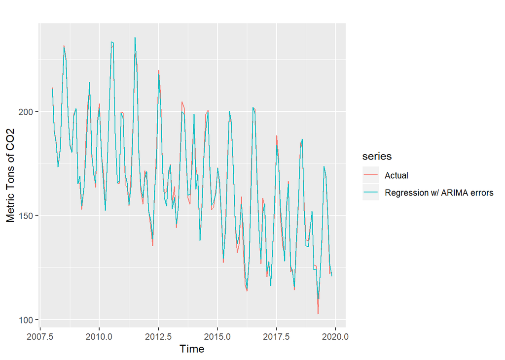

```r
CO2_RARIMA1<-auto.arima(CO2_Window,xreg=consumption_window,D=1,lambda=0)
autoplot(cbind(Actual=CO2_Window,"Regression w/ ARIMA errors"=CO2_RARIMA1$fitted), xlab='Time',ylab="Metric Tons of CO2", facets=FALSE)
```

#### Check model residuals for autocorrelation

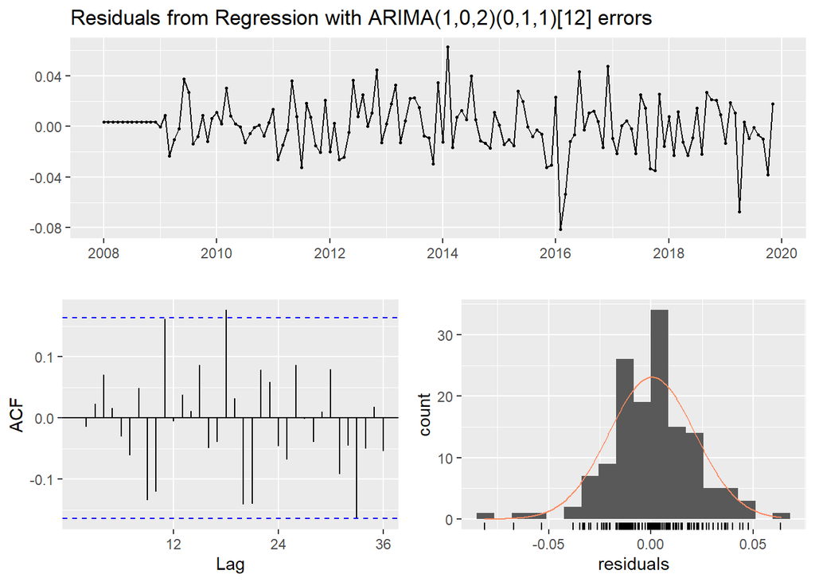

```
##
##  Ljung-Box test
##
## data:  Residuals from Regression with ARIMA(1,0,2)(0,1,1)[12] errors
## Q* = 27.341, df = 18, p-value = 0.07282
##
## Model df: 6.   Total lags used: 24
```

```r
checkresiduals(CO2_RARIMA1)
```